```python
import numpy as np
import scipy.stats as sts
import scipy.special as sc
import matplotlib.pyplot as plt
import random
%matplotlib inline
```

# Гречишкин Денис, ПМ-31

# Лабораторная работа №2

$\newline$

## ЧАСТЬ 2.4 (Примеры для совместного обсуждения)

## Пример 1

```
выборка
 [0 2 1 1 0 2 1 2 2 0 2 0 3 1 0 1 0 3 2 1 3 2 1 0 0 0 1 2 2 0 0 1 2 1 2 1 0
 0 0 2]
набор различных значений выборки:
 zk =  [0 1 2 3]
относительные частоты различых элементов выборки:
 [0.35  0.275 0.3   0.075]
статистический ряд:
 zk 	 pk
0 	 0.35
1 	 0.275
2 	 0.3
3 	 0.075
```

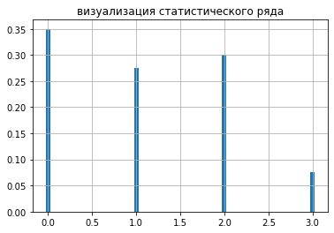

```python
#генерируем сл. выборку
nv = 40
n = 5
p = 0.2
x = np.random.binomial(n, p, nv)
print('выборка', '\n', x)
z = np.sort(list(set(x)))
print('набор различных значений выборки:', '\n', 'zk = ', z)
pz = np.bincount(x) / nv
print('относительные частоты различых элементов выборки:', '\n', pz)
#представим статистический ряд как двумерный
z_pz = np.stack((z, pz))
print('статистический ряд:', '\n', 'zk \t pk')
for k in range(len(z)):
    print(z[k], '\t', pz[k])
plt.title('визуализация статистического ряда')
plt.bar(z, pz, width = 0.05)
plt.grid(True)
```

## Пример 2

```python
#моделирование эксперимента
n = 10000
f = np.full(n, 0)
x = np.array([1, 2, 3, 4, 5, 6])
for k in np.arange(n):
    v = random.sample('123456', 3)
    if (('2' in v) or ('3' in v)):
            f[k] = 0
    else:
        f[k] = 1
print('выборка', '\n', f)
z = np.sort(list(set(f)))
pz = np.bincount(f) / n
zpz = np.stack((z, pz))
print('статистический ряд:', '\n', 'zk \t pk')
for k in range(len(z)):
    print(z[k], '\t', pz[k])
```

```
выборка
 [0 0 0 ... 1 1 0]
статистический ряд:
 zk 	 pk
0 	 0.8007
1 	 0.1993
```

Теоретические расчеты

```python
p_1 = sc.comb(4, 3)/sc.comb(6, 3)
p_0 = 1 - sc.comb(4, 3)/sc.comb(6, 3)
print('P{X = 0} =', p_0)
print('P{X = 1} =', p_1)
```

```
P{X = 0} = 0.8
P{X = 1} = 0.2
```

## Пример 3

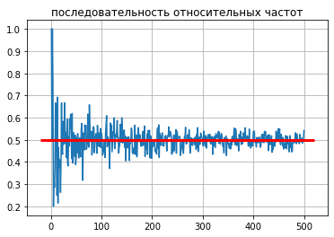

```python
#иллюстрация теоремы Бернулли
nn = 500
xx = np.array([0, 1])
pp = np.array([0.5, 0.5])
ff = np.zeros(nn)
for n in (np.arange(nn) + 1):
    vb = np.random.choice(xx, size = n, p = pp)
    ff[n - 1] = np.sum(vb) / n
plt.plot(np.arange(nn) + 1, ff)
plt.hlines(0.5, - 20, nn + 20, colors = 'r', lw = 3)
plt.title('последовательность относительных частот')
plt.grid(True)
```

$\newline$

# Часть 2.5 (Задания для самостоятельного выполнения)

## Задание 1:

Задайте рядом распределения дискретную случайную величину, число возможных значений которой совпадает с длиной вашей фамилии (вероятности выберите на ваше усмотрение). Сгенерируйте выборки объемов 100 и 1000; для каждой из них составьте статистический ряд, визуализируйте его и сопоставьте с рядом распределения случайной величины

## Решение:

составим ряд распределения случайной величины X, затем составим выборку объёма 100 с помощью функции np.random.choice() по закону распределения и составим статистический ряд

```
Ряд распределения случайной величины X

x_k 	 P{X = x_k}
0 	 0.12
1 	 0.15
2 	 0.08
3 	 0.23
4 	 0.1
5 	 0.05
6 	 0.09
7 	 0.07
8 	 0.11
Выборка объёма 100: [4 1 3 3 8 6 8 1 3 4 2 3 8 2 2 1 4 8 3 4 4 3 8 0 3 3 5 4 8 3 8 8 6 1 3 7 8
 7 5 0 1 4 7 6 3 1 7 1 8 6 1 1 0 0 3 1 7 7 0 0 3 4 1 5 8 8 3 3 7 0 7 0 4 3
 3 3 5 1 7 0 2 3 1 7 3 3 4 1 5 1 3 6 1 7 6 8 7 0 5 3]
набор различных значений выборки:
 zk =  [0 1 2 3 4 5 6 7 8]
относительные частоты различых элементов выборки:
 [0.1  0.16 0.04 0.23 0.1  0.06 0.06 0.12 0.13]
статистический ряд:
 zk 	 pk
0 	 0.1
1 	 0.16
2 	 0.04
3 	 0.23
4 	 0.1
5 	 0.06
6 	 0.06
7 	 0.12
8 	 0.13
```

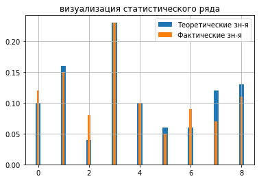

```python
nv1 = 100
n = 9
xs = [k for k in range(n)]
ps = [0.12, 0.15, 0.08, 0.23, 0.1, 0.05, 0.09, 0.07, 0.11]
print("Ряд распределения случайной величины X \n")
print('x_k \t P{X = x_k}')
for k in range(len(xs)):
    print(xs[k], '\t', ps[k])


#сформируем выборку объёма 100
x1 = np.random.choice(xs, size = nv1, replace = True, p = ps)
print('Выборка объёма 100:', x1)

#найдем набор значений этой выборки и отн. частоты
z1 = np.sort(list(set(x1)))
print('набор различных значений выборки:', '\n', 'zk = ', z1)
pz1 = np.bincount(x1) / nv1
print('относительные частоты различых элементов выборки:', '\n', pz1)

#представим эту информацию в виде таблицы и гистограммы
#на гистограмму также добавим теоретические значения вероятностей
print('статистический ряд:', '\n', 'zk \t pk')
for k in range(len(z1)):
    print(z1[k], '\t', pz1[k])
plt.title('визуализация статистического ряда')
plt.bar(z1, pz1, width = 0.2, label = 'Теоретические зн-я')
plt.bar(z1, ps, width = 0.1, label = 'Фактические зн-я')
plt.grid(True)
plt.legend()
```

Теперь сгенерируем выборку объема 1000 и проделаем с ней всё то же самое что и с выборокой объёма 100

```
Ряд распределения случайной величины X

x_k 	 P{X = x_k}
0 	 0.12
1 	 0.15
2 	 0.08
3 	 0.23
4 	 0.1
5 	 0.05
6 	 0.09
7 	 0.07
8 	 0.11
Выборка объёма 1000: [8 2 4 7 3 1 0 2 8 3 8 1 0 2 3 3 7 3 3 0 7 3 6 3 3 2 0 4 6 6 5 3 4 1 3 6 5
 6 3 0 3 0 0 0 0 7 3 3 5 1 8 1 1 4 2 2 0 5 6 3 5 3 3 4 2 8 3 2 3 0 4 2 6 2
 3 0 7 0 4 2 5 1 8 0 6 6 4 4 3 4 3 7 3 8 3 1 1 5 6 8 0 4 8 8 5 1 7 3 6 4 1
```

[output cut: 40 more lines]

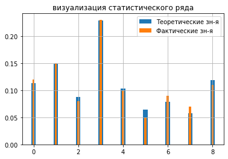

```python
nv2 = 1000
n = 9
xs = [k for k in range(n)]
ps = [0.12, 0.15, 0.08, 0.23, 0.1, 0.05, 0.09, 0.07, 0.11]
print("Ряд распределения случайной величины X \n")
print('x_k \t P{X = x_k}')
for k in range(len(xs)):
    print(xs[k], '\t', ps[k])


#сформируем выборку объёма 1000
x2 = np.random.choice(xs, size = nv2, replace = True, p = ps)
print('Выборка объёма 1000:', x2)

#найдем набор значений этой выборки и отн. частоты
z2 = np.sort(list(set(x2)))
print('набор различных значений выборки:', '\n', 'zk = ', z2)
pz2 = np.bincount(x2) / nv2
print('относительные частоты различых элементов выборки:', '\n', pz2)

#представим эту информацию в виде таблицы и гистограммы
#на гистограмму также добавим теоретические значения вероятностей
print('статистический ряд:', '\n', 'zk \t pk')
for k in range(len(z2)):
    print(z2[k], '\t', pz2[k])
plt.title('визуализация статистического ряда')
plt.bar(z2, pz2, width = 0.2, label = 'Теоретические зн-я')
plt.bar(z2, ps, width = 0.1, label = 'Фактические зн-я')
plt.legend()
plt.grid(True)
```

И сравним гистограммы с практическими значениями вероятностей для выборок объёма 100 и 1000

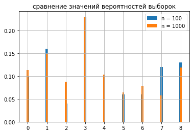

```python
plt.title('сравнение значений вероятностей выборок')
plt.bar(z1, pz1, width = 0.13, label = 'n = 100')
plt.bar(z2, pz2, width = 0.1, label = 'n = 1000')
plt.legend()
plt.grid(True)
```

$\newline$

## Задание 2:

Проводятся последовательные испытания шести приборов, надежность каждого из которых равна 0,6. Каждый следующий прибор испытывается только в том случае, когда предыдущий оказался надежным. Случайная величина 𝑋 – число испытанных в данном эксперименте приборов. 1) Составьте аналитически закон распределения случайной величины, найдите математическое ожидание и дисперсию. 2) Путем компьютерного моделирования эксперимента (исходя непосредственно из его описания, не используя закон распределения из п. 1) получите выборку объема 300. Визуализируйте статистический ряд и сопоставьте его с законом распределения случайной величины. 3) Проиллюстрируйте теорему Чебышёва для одинаково распределенных слагаемых

## Решение:$\newline$ Пункт 1: Составим закон распределения случайной величины в виде ряда распределения и найдём математическое ожидание и дисперсию с помощью известных нам формул мат. ожидания и дисперсии.

Т.к X - число испытанных приборов, то результат испытаний нам не важен => число испытанных приборов будет от 1 до 6. Вероятность того что прибор окажется надежным равна 0,6; значит 1 прибор будем испытан только в том случае когда он оказался ненадежным, т.е будет иметь вероятность 0,4. По той-же логике 2 прибора будут испытаны только в том случае когда первый прибор оказался надежным, а второй - нет, т.е 2 прибора будут испытаны с верояностью $0,6 \cdot 0,4$. И так далее до случая с пятью приборами. В случае с шестью приборами, нам не важен результат испытания последнего прибора, т.к он в любом случае будет испытан => вероятность испытания шести приборов 6 приборов будет равна $0,6^6 + 0,6^5 \cdot 0,6 = 0,6^5 \cdot (0,6 + 0,4) = 0,6^5$.

```python
n = 6
x_znach = [k for k in range(1, n + 1)]
p1 = 0.6
p_znach = [(1 - p1), p1*(1 - p1), p1**2*(1 - p1),\
           p1**3*(1 - p1), p1**4*(1 - p1), p1**5]

print('Закон распределения СВ X в виде ряда распределения', \
      '\n', 'xk \t pk')
for k in range(len(x_znach)):
    print(x_znach[k], '\t', p_znach[k])

#найдём мат ожидание с помошью стандартной формулы для мат.ожидания
m = 0
for k in range(n):
    m += x_znach[k] * p_znach[k]
print('мат. ожидание равно:', m)

#найдём дисперсию с помошью упрощённой формулы для дисперсии
d = 0
for k in range(n):
    d += x_znach[k]**2 * p_znach[k]
d -= (m)**2
print('дисперсия равна:', d)
```

```
Закон распределения СВ X в виде ряда распределения
 xk 	 pk
1 	 0.4
2 	 0.24
3 	 0.144
4 	 0.08639999999999999
5 	 0.05184
6 	 0.07775999999999998
мат. ожидание равно: 2.3833599999999997
дисперсия равна: 2.4533551104000004
```

## Пункт 2:

проведем компьютерное моделирование эксперимента - составим выборку из натуральных чисел от 0 до 6 размером 300, найдем набор значений этой выборки и отн. частоты и визуализируем этот статистический ряд

Выборку будем составлять следующим образом: составим массив из 300 единиц(во всех 300 испытаниях хотя-бы 1 прибор будет испытан) и будем испытывать следующие приборы. Переменная add будет индексатором того что следующий прибор работает(1 - если прибор работает, 0 - если прибор не работает). По условию, прибор исправен с вероятностью 0.6, т.е переменная add может принять значение 1 с вероятностью 0,6 и 0 с вероятностью 0,4. Далее, прибавляем add к элементу массива selection и проверяем, чему равна переменная add: если она равна 0, то мы прекращаем испытания и переходим к следующему эксперименту, в противном случае продолжаем испытания до тех пор пока количество приборов не будет равно 6.

```
Выборка объёма 300: [1 5 2 2 1 3 1 1 2 2 4 2 2 6 4 1 2 3 2 4 2 6 1 1 1 4 1 1 4 6 2 2 1 2 2 2 4
 3 1 3 1 1 4 6 2 1 2 2 2 6 1 6 1 2 6 6 2 5 3 1 2 2 3 1 1 2 2 1 6 5 6 4 1 1
 1 6 1 5 2 2 1 1 1 1 2 1 1 1 4 2 3 4 6 5 2 2 4 1 1 3 2 3 5 2 1 3 2 1 2 4 1
 1 2 1 2 2 1 3 3 2 1 6 2 1 2 6 3 3 6 2 2 1 1 2 2 3 1 1 5 4 1 1 4 1 1 4 2 2
 3 5 1 1 2 1 1 4 2 1 1 1 2 3 1 5 1 2 1 1 2 5 4 3 3 1 6 1 1 1 3 4 6 4 3 1 2
 1 2 1 1 1 3 1 1 4 1 6 1 4 1 2 1 6 1 1 1 2 2 3 1 2 1 1 1 6 1 1 1 1 2 2 3 6
 2 2 3 1 4 1 2 1 4 1 1 1 3 1 1 4 2 2 1 2 1 6 1 3 6 1 2 2 1 1 1 1 1 3 1 3 1
 2 1 6 1 1 5 1 1 5 4 1 3 3 3 1 1 2 1 4 3 3 2 2 2 6 3 6 1 6 1 6 3 3 6 1 3 2
 1 1 6 1]
набор различных значений выборки:
 zk =  [1 2 3 4 5 6]
относительные частоты различых элементов выборки:
 [0.40333333 0.24333333 0.12666667 0.08666667 0.04       0.1       ]
статистический ряд:
 zk 	 pk
1 	 0.4033333333333333
2 	 0.24333333333333335
3 	 0.12666666666666668
4 	 0.08666666666666667
5 	 0.04
6 	 0.1
```

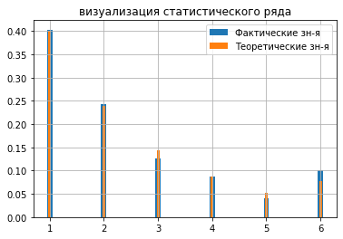

```python
size = 300
Selection = np.full(size, 1)
n1 = 1
size1 = 1
for i in range(size):
    add = np.random.binomial(n1, p1, size1)
    Selection[i] += add
    if add > 0:
        while ((add > 0) and (Selection[i] != 6)):
            add = np.random.binomial(n1, p1, size1)
            Selection[i] += add
print('Выборка объёма 300:', Selection)
#найдем набор значений этой выборки и отн. частоты
z = np.sort(list(set(Selection)))
print('набор различных значений выборки:', '\n', 'zk = ', z)
Sel = np.bincount(Selection) / size
Sel = Sel[1:]
print('относительные частоты различых элементов выборки:', '\n', Sel)

#представим эту информацию в виде таблицы и гистограммы
print('статистический ряд:', '\n', 'zk \t pk')
for k in range(len(z)):
    print(z[k], '\t', Sel[k])

plt.bar(z, Sel, width = 0.1, label = 'Фактические зн-я')
plt.bar(x_znach, p_znach, width = 0.05, label = 'Теоретические зн-я')
plt.legend()
plt.title('визуализация статистического ряда')
plt.grid(True)
```

## Пункт 3:

Теорема Чебышева заключается в следующем: Если $X_1, X_2, X_3, ..., X_n$ попарно независимые случайные величины, причем дисперсии их равномерно ограничены (не превышают постоянного числа C), то, как бы мало ни было положительное число $epsilon$, вероятность неравенства: $$P(|\frac{X_1 + X_2 + X_3 + ... + X_n}{n} - \frac{M[X_1] + M[X_2] + M[X_3] + ... + M[X_n]}{n}| < \epsilon) \rightarrow 1 \newline$$ при $$n \rightarrow \infty$$ $\newline$ Т.к в данном эксперименте мат ожидания всех случайных величин одинаково и равно m, то необходимо рассмотреть выражение: $$P(|\frac{X_1 + X_2 + X_3 + ... + X_n}{n} - m| < \epsilon) \rightarrow 1 \newline$$ при $$n \rightarrow \infty$$ $\newline$ Чтобы эту теорему продемонстрировать, построим графики мат ожидания и среднего арифметического случайных величин от размера выборки. Для того чтобы построить второй график, создадим массив суммы значений случаных величин и среднего арифметического случаных величин и будем их пополнять значениями.

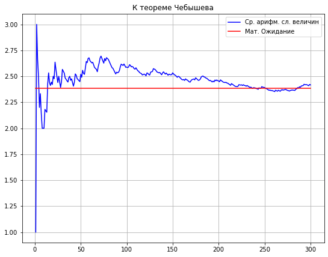

```python
summ = []
summ.append(Selection[0])
sr_ar = []
sr_ar.append(Selection[0])
x = np.arange(1, 301, 1)
for i in range(1, size):
    summ.append(summ[i - 1] + Selection[i])
    sr_ar.append(summ[i] / (i + 1))
plt.figure(figsize = (9, 7))
plt.plot(x, sr_ar, 'b', label = 'Ср. арифм. сл. величин')
plt.plot(x, m + 0*x, 'r', label = 'Мат. Ожидание')
plt.title('К теореме Чебышева')
plt.grid(True)
plt.legend()
```

Из графика видим, что чем больше число испытаний, тем ближе ср. арифм. сл. величин к мат. ожиданию.

$\newline$

## Задание 3:

Иван и Олег решают следующую задачу «20 футбольных команд, среди которых 4 призера (А, Б, В, Г) предыдущего первенства, по жеребьевке разбиваются на 4 занумерованные подгруппы по 5 команд. Нужно найти вероятность события С = {в первую и вторую подгруппу не попадет ни один из призеров}».

Решать задачу друзья начали с построения множества элементарных исходов Ω. Иван подумал, что поскольку в событии С говорится только о призерах, то при решении задачи про остальные команды можно вовсе «забыть». И предложил образовать Ω из упорядоченных наборов длины четыре, в которых первый элемент – это номер команды, в которую попал призер А, второй элемент – номер команды, в которую попал призер Б, и т.д.

Олег засомневался, что при таком построении множества элементарных исходов можно будет использовать классическую схему. У него есть гипотеза, что включенные в Ω исходы неравновозможны. Ваша задача – экспериментальным путем опровергнуть или «подтвердить» гипотезу Олега. Многократно проведите компьютерную «жеребьевку» 20 команд и сопоставьте частоты, с которыми наблюдаются результаты, из которых Иван предложил составить множество элементарных исходов. К каким выводам вы пришли?

## Решение:

для начала найдём мощность множества элементарных исходов которое предложил Иван: каждый из четырёх призёров может попасть в одну из 4 подгрупп => $|\omega| = 4 \cdot 4 \cdot 4 \cdot 4 = 256$ вариантов

Следовательно, каждое из элементарных исходов должно иметь вероятность, равную $\frac{1}{256} = 0.00390625$.

Теперь проделаем многократную жребьевку, найдем частоты появления.

```python
#для того чтобы сократить код,
#напишем вспомогательную функцию поиска элемента в массиве
amount = 10000
def search(elem, sel):
    k = 0
    for s in sel:
        if elem == s:
            k += 1
    return k

#теперь создадим множество элементарных исходов
omega = []
elems = ['1', '2', '3', '4']
for elem1 in elems:
    for elem2 in elems:
        for elem3 in elems:
            for elem4 in elems:
                omega.append(elem1 + elem2 + elem3 + elem4)

#далее создадим выборку достаточно большого размера из жребьёвок
#и посмотрим, с какими частотами встречаются элементы из множества
#элементарных исходов
Selection = [''.join(random.choices(elems, k=4)) for n in range(amount)]
print('статистический ряд:', '\n', 'zk \t pk \t отличие от 1/256')
for elem in omega:
    pk = search(elem, Selection) / amount
    print(elem, '\t', pk, '\t', np.abs(pk - 0.00390625))
```

```
статистический ряд:
 zk 	 pk 	 отличие от 1/256
1111 	 0.0037 	 0.00020624999999999984
1112 	 0.0048 	 0.0008937499999999996
1113 	 0.0043 	 0.00039375
1114 	 0.0039 	 6.250000000000179e-06
1121 	 0.0045 	 0.0005937499999999997
1122 	 0.0036 	 0.0003062500000000001
1123 	 0.0045 	 0.0005937499999999997
1124 	 0.0041 	 0.00019375000000000035
1131 	 0.0039 	 6.250000000000179e-06
1132 	 0.0043 	 0.00039375
1133 	 0.0035 	 0.00040624999999999993
1134 	 0.0039 	 6.250000000000179e-06
1141 	 0.0033 	 0.00060625
```

[output cut: 243 more lines]

$\newline$

## Задание 4, Вариант 7:

Для сборки требуется 5 однотипных детали. Всего имеется 10 деталей, из которых только 8 не имеют брака. Наудачу отбираются 6 деталей (одна деталь «про запас»). 1) Проведите компьютерное моделирование эксперимента, непосредственно исходя из его описания. 2) Проиллюстрируйте теорему Бернулли, построив график зависимости относительной частоты наблюдения события 𝐴 = «можно будет произвести сборку прибора» от длины серии экспериментов.

## Решение:$\newline$

## Пункт 1: Проведем компьтерное моделирование, используя функцию random.sample(). Пусть 0 - индикатор того что деталь неисправна, а 1 - индикатор того что деталь исправна.

```python
#моделирование эксперимента
n = 10000
f = np.full(n, 0)
for k in np.arange(n):
    v = random.sample('0011111111', 6)
    if (not('0' in v) or v.count('0') == 1):
            f[k] = 1
    else:
        f[k] = 0
print('выборка', '\n', f)

#формируем статистический ряд
z = np.sort(list(set(f)))
p_z = np.bincount(f) / n
print('статистический ряд:', '\n', 'zk \t pk')
for k in range(len(z)):
    print(z[k], '\t', pz[k])
```

[output not shown]

## Пункт 2: Перед тем как проиллюстрировать теорему Бернулли, найдем вероятность того что можно произвести сборку прибора.

$\newline$ Общее количество выриантов выбрать 6 деталей из 10 равно $С_{10}^6$ (т.к повтор невозможен, а порядок - не важен) При этом, нам подходят только те случаи, когда все детали годные, либо только одна негодная. $\newline$ Всего вариантов выбрать 6 годных деталей $С_{8}^6$, а вариантов выбрать 5 годных деталей и одну негодную - $С_{8}^5 \cdot 2$, $\newline$ Тогда получаем $$P_{иск.} = \frac{С_{8}^6 + С_{8}^5 \cdot 2}{С_{10}^6} = \frac{2}{3}$$

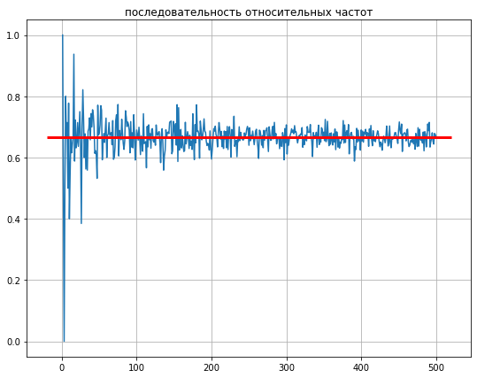

```python
#иллюстрация теоремы Бернулли
nn = 500
xx = np.array([0, 1])
pp = np.array([1/3, 2/3])
ff = np.zeros(nn)


for n in (np.arange(nn) + 1):
    vb = np.random.choice(xx, size = n, p = pp)
    ff[n - 1] = np.sum(vb) / n
plt.figure(figsize = (9, 7))
plt.plot(np.arange(nn) + 1, ff)
plt.hlines(2/3, - 20, nn + 20, colors = 'r', lw = 3)
plt.title('последовательность относительных частот')
plt.grid(True)
```